# Mortalidade (SIM-DO)

Eixo central dos EIM · mortalidade padronizada e infantil · incidência ao nascimento por traçadora · 2010–2024

6.518

óbitos por EIM (causa básica, core)

46.966

teto core+limítrofe+envelope (bracketing)

30,0 anos

idade mediana ao óbito (core)

70,0 anos

idade mediana ao óbito (teto)

713

óbitos infantis por EIM (<1 ano)

Nos EIM a mortalidade é um eixo central do painel: são doenças de **alta letalidade precoce**, e o SIM é a base do DATASUS com **melhor cobertura e completude**. O SIM cobre **2010–2024** com dados definitivos; o ano seguinte, ainda preliminar no DATASUS, fica fora das taxas.

**Cobertura boa não é o mesmo que definição de caso válida.** Em doença rara, a causa básica sofre os **dois** vieses ao mesmo tempo:

- **Subnotificação** — o EIM verdadeiro é declarado como sepse, insuficiência respiratória ou encefalopatia, e o código E sequer aparece na DO. Esse óbito é **invisível a este painel**: não entra no numerador nem no denominador.
- **Sobrenotificação** — códigos inespecíficos do capítulo E (E88.9 “distúrbio metabólico não especificado”, E78, E85 adquirida) são usados em óbito de adulto/idoso sem relação com EIM.

Por isso **não** se deve ler “3,9% dos óbitos que mencionam EIM têm EIM como causa básica” como prova de que a doença *mata diretamente*: o denominador é o conjunto que o **próprio filtro** capturou, e o filtro varre `causabas` + linhas. Um EIM que nunca recebeu código E não vira “contribuinte” — vira zero. Esse percentual descreve a **estrutura da lookup**, não a letalidade da doença.

A leitura honesta é o **intervalo** 6.518–46.966 óbitos (core → teto com limítrofe e envelope), e a diferença entre as **idades medianas ao óbito** das duas camadas (30,0 vs 70,0 anos) é o melhor termômetro de quanta contaminação de adulto o teto carrega.

**Mortalidade registrada, não prevalência.** A mortalidade padronizada por EIM está **em alta** em 2010–2024 (+2,4%/ano, IC95% +1,8 a +3,1): 0,19 (2010) → 0,17 (2012, mín.) → 0,25 (2022, máx.) → 0,23 (2024) por 100 mil. Cresce bem menos que a detecção ambulatorial, e o aumento é compatível com **melhor reconhecimento do EIM na declaração de óbito** e mais diagnóstico — não necessariamente com mais mortes pela doença. Em 2020 os óbitos com EIM como causa básica variaram −12,9% em relação a 2019: a pandemia disputou a causa básica. A variação por UF combina incidência, acesso a diagnóstico/tratamento e **qualidade de codificação** da declaração de óbito.

## Onde o EIM aparece na Declaração de Óbito

| posicao | obitos | % |
| --- | --- | --- |
| Causa básica — camada core | 6.518 | 3,9 |
| Causa básica — limítrofe/envelope (teto) | 40.448 | 24,4 |
| Só em outra linha (contribuinte) | 118.596 | 71,6 |

Descreve a estrutura da captura, NÃO a letalidade: o denominador é o conjunto que o próprio filtro capturou (causabas + linhas). Um EIM declarado como sepse, sem nenhum código E na DO, não aparece como 'contribuinte' — é invisível a esta tabela.

## Composição do numerador — por camada e por CID de 4 dígitos

Numa definição de caso feita de **prefixos**, o número final é tão bom quanto os códigos que entram nele. Esta seção abre o numerador para auditoria: **nenhum número deste painel deve ser citado sem olhar antes esta tabela.**

| Camada | Óbitos | % |
| --- | --- | --- |
| Core — EIM inequívoco (definição primária) | 6.518 | 13,9 |
| Envelope — abriga condição comum não-EIM (TETO) | 36.044 | 76,7 |
| Limítrofe — EIM porém inespecífico | 4.404 | 9,4 |

Só a linha 'core' entra nos números primários do painel. As camadas limítrofe e envelope compõem o TETO de subcodificação (bracketing) e nunca são contadas como caso.

| CID-10 | Camada | Óbitos | % | Idade mediana ao óbito |
| --- | --- | --- | --- | --- |
| E788 | envelope | 14.568 | 31,0 | 73,0 anos |
| E889 | envelope | 7.797 | 16,6 | 73,0 anos |
| E780 | envelope | 3.622 | 7,7 | 72,0 anos |
| E789 | envelope | 3.289 | 7,0 | 73,0 anos |
| E840 | core | 2.529 | 5,4 | 57,0 anos |
| E785 | envelope | 1.716 | 3,7 | 72,0 anos |
| E835 | limitrofe | 1.457 | 3,1 | 71,0 anos |
| E854 | envelope | 1.034 | 2,2 | 72,0 anos |
| E859 | envelope | 850 | 1,8 | 68,5 anos |
| E782 | envelope | 766 | 1,6 | 72,0 anos |
| E880 | limitrofe | 591 | 1,3 | 65,0 anos |
| E752 | core | 590 | 1,3 | 12,0 anos |
| E831 | envelope | 562 | 1,2 | 61,0 anos |
| E781 | envelope | 453 | 1,0 | 48,0 anos |
| E888 | envelope | 449 | 1,0 | 68,0 anos |
| E849 | core | 414 | 0,9 | 59,0 anos |
| G120 | limitrofe | 346 | 0,7 | 2,0 anos |
| E830 | core | 325 | 0,7 | 28,0 anos |
| E784 | envelope | 315 | 0,7 | 71,0 anos |
| D66 | limitrofe | 294 | 0,6 | 45,0 anos |
| E778 | limitrofe | 253 | 0,5 | 75,0 anos |
| E729 | limitrofe | 232 | 0,5 | 59,0 anos |
| E740 | core | 226 | 0,5 | 8,0 anos |
| E725 | core | 217 | 0,5 | 72,0 anos |
| E763 | limitrofe | 199 | 0,4 | 15,0 anos |

Idade mediana alta (≥60 anos) num código de camada envelope/limítrofe é a assinatura de garbage code em declaração de óbito de idoso — não de EIM. É por isso que só a camada core entra no número primário.

**Como usar esta tabela.** Um EIM é doença de **letalidade concentrada no período neonatal/lactente**. Portanto: código com **idade mediana ao óbito ≥ 60 anos e volume alto** é suspeito de ser código inespecífico usado em óbito de idoso, não caso de EIM. Os candidatos conhecidos dentro de E70–E90 são **E88.9** (distúrbio metabólico não especificado), **E78** (dislipidemia), **E85.3/E85.8/E85.9** (amiloidose adquirida), **E83.1** (hemocromatose) e **E79.0** (gota) — todos classificados como *envelope* na lookup, e todos **fora** do número primário. Os *garbage codes* clássicos **E86** (depleção de volume) e **E87** (distúrbios hidroeletrolíticos) **não** integram a definição de caso deste painel em nenhuma camada.

## Mortalidade padronizada por EIM (2010–2024)

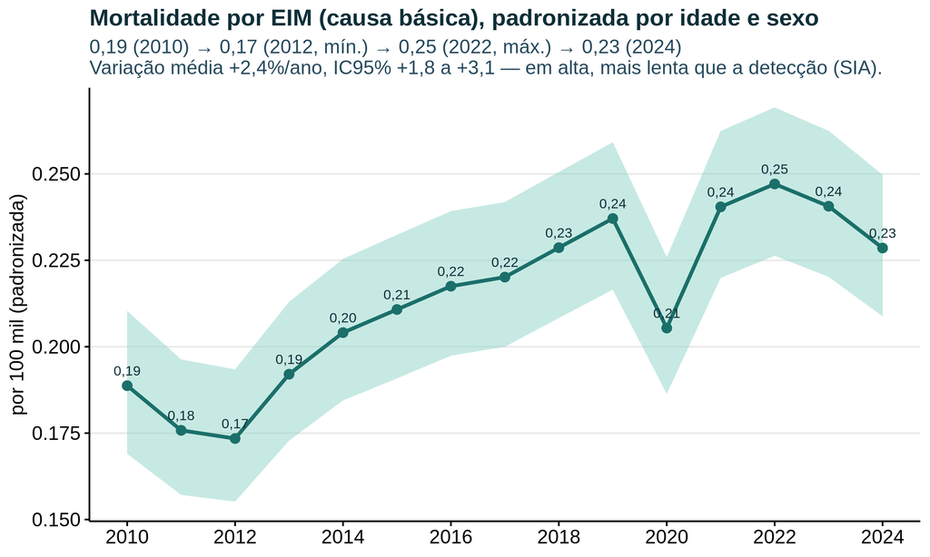

## Pirâmide de óbitos — sexo × idade

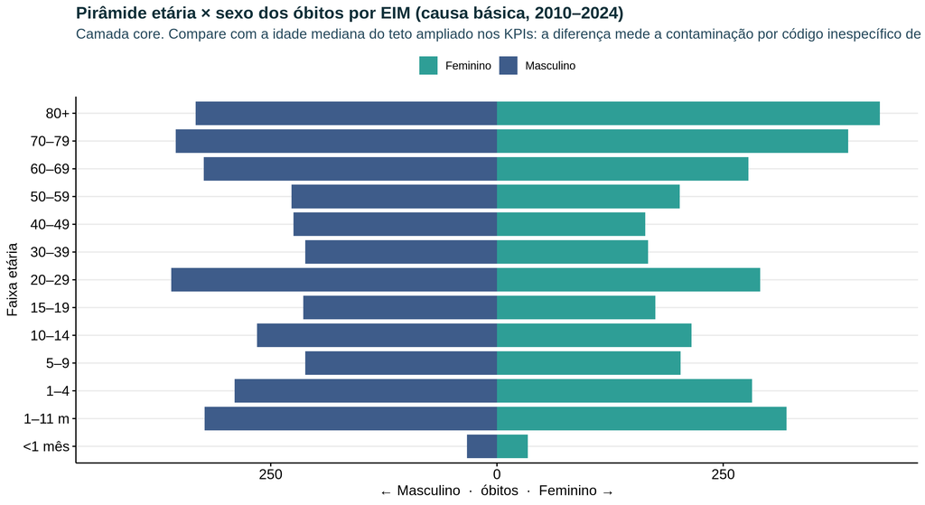

## Mortalidade infantil por EIM / 100 mil nascidos vivos

| Ano | Óbitos <1 ano | Nascidos vivos | por 100k NV | IC95% |
| --- | --- | --- | --- | --- |
| 2,010 | 40 | 2.861.868 | 1,40 | 1,00–1,90 |
| 2,011 | 57 | 2.913.160 | 1,96 | 1,48–2,54 |
| 2,012 | 53 | 2.905.789 | 1,82 | 1,37–2,39 |
| 2,013 | 51 | 2.904.027 | 1,76 | 1,31–2,31 |
| 2,014 | 45 | 2.979.259 | 1,51 | 1,10–2,02 |
| 2,015 | 57 | 3.017.668 | 1,89 | 1,43–2,45 |
| 2,016 | 42 | 2.857.800 | 1,47 | 1,06–1,99 |
| 2,017 | 48 | 2.923.535 | 1,64 | 1,21–2,18 |
| 2,018 | 54 | 2.944.932 | 1,83 | 1,38–2,39 |
| 2,019 | 49 | 2.849.146 | 1,72 | 1,27–2,27 |
| 2,020 | 40 | 2.730.145 | 1,47 | 1,05–2,00 |
| 2,021 | 51 | 2.677.101 | 1,91 | 1,42–2,50 |
| 2,022 | 46 | 2.561.922 | 1,80 | 1,31–2,39 |
| 2,023 | 45 | 2.537.576 | 1,77 | 1,29–2,37 |
| 2,024 | 35 | 2.389.325 | 1,46 | 1,02–2,04 |

Denominador SINASC (nascidos vivos). Óbito infantil por EIM é indicador robusto (idade neonatal bem preenchida no SIM).

## Incidência ao nascimento por traçadora — dissociação incidência × mortalidade

| Traçadora | Óbitos <1a | Mort. inf./100k NV | IC95% | Detecção 1º ano (SIH / SIA) | Incid. lit. [VERIFICAR] |
| --- | --- | --- | --- | --- | --- |
| Biotinidase (E88.9 TETO) | 409 | 0,97 | 0.88–1.07 | 0 / 0 | ~1:60.000 [VERIFICAR] |
| Fibrose cistica | 312 | 0,74 | 0.66–0.83 | 2.463 / 123.098 | ~1:8.000 [VERIFICAR] |
| HAC | 62 | 0,15 | 0.11–0.19 | 489 / 24.239 | ~1:12.000 [VERIFICAR] |
| Gaucher Fabry NPC | 56 | 0,13 | 0.10–0.17 | 45 / 112 |  |
| Pompe | 53 | 0,13 | 0.09–0.16 | 193 / 212 |  |
| Hipotireoidismo cong | 36 | 0,09 | 0.06–0.12 | 110 / 90.017 | ~1:2.500 [VERIFICAR] |
| Ciclo ureia | 30 | 0,07 | 0.05–0.10 | 40 / 187 | ~1:35.000 (grupo) [VERIFICAR] |
| MSUD | 23 | 0,05 | 0.03–0.08 | 99 / 147 | ~1:130.000 [VERIFICAR] |
| Galactosemia | 20 | 0,05 | 0.03–0.07 | 129 / 471 | ~1:40.000 [VERIFICAR] |
| PKU | 5 | 0,01 | 0.00–0.03 | 713 / 19.320 | ~1:10.000 [VERIFICAR] |
| MPS outras | 2 | N<5 (suprimido) | N<5 (suprimido) | 98 / 134 |  |
| MPS I | 1 | N<5 (suprimido) | N<5 (suprimido) | 28 / 120 |  |
| MPS II | 1 | N<5 (suprimido) | N<5 (suprimido) | 12 / 78 |  |
| Toxo congenita | 0 | N<5 (suprimido) | não medido nesta base (painel pezinho) | 0 / 0 |  |
| Talassemia | 0 | N<5 (suprimido) | não medido nesta base (painel pezinho) | 0 / 0 |  |
| Doenca falciforme | 0 | N<5 (suprimido) | não medido nesta base (painel pezinho) | 0 / 0 |  |
| SCID | 0 | N<5 (suprimido) | não medido nesta base (painel pezinho) | 0 / 0 |  |

Mortalidade infantil = SIM causa básica <1 ano / 100 mil NV (SINASC), IC Poisson exato, supressão N<5. 'Detecção 1º ano' via SIA são registros, não crianças (idade SIA mal preenchida). Incidência da literatura [VERIFICAR].

A **dissociação incidência × mortalidade** é o diferencial deste painel: separa o que a triagem já resolve do que ainda mata.

## Limitações

- **SIM cobre 2010–2024** (definitivos); o ano preliminar fica fora das taxas.
- **Definição de caso = camada core** (corrigido; antes o KPI usava o modo “ampliado”, que incluía a camada envelope e não era comparável com SIA/SIH). O teto ampliado continua publicado ao lado, como *bracketing*. Ver a composição do numerador acima e `ref/avaliacao_critica_externa.md`.
- **Sem suavização espacial** nos mapas por UF: em evento raro, UF de população pequena (AC, RR, AP) oscilam por ruído. Ler os extremos com cautela.
- Mortalidade infantil (SIM) é robusta; **“detecção 1º ano” via SIA são registros, não crianças** (idade SIA mal preenchida) → indica **intensidade**, não incidência.
- Valores de incidência da literatura `[VERIFICAR]`; supressão de N<5 nas taxas divulgadas.
- Mortalidade **registrada**, não prevalência; grupo heterogêneo (não interpretar “total EIM”).